# Final Project - Part 1

## Authors: Mark Arshavsky, Alex Dahan, Tejas Pulavarti

## Introduction:

- Motivation: The motivation behind the question of whether individuals with a Master's degree earn more than those with a Bachelor's degree can be strongly supported by statistics and research findings. For instance, according to data from the U.S. Bureau of Labor Statistics, as of 2022, individuals with a Master's degree had a median usual weekly earnings of approximately 1661 USD while those with a Bachelor's degree had median earnings of about 1432 USD. Such statistics highlight the tangible economic benefits associated with higher levels of education and demonstrate the significance of this research question in guiding educational choices.
- Importance: The question of whether individuals with a Master's degree earn more than those with a Bachelor's degree is very important. Firstly, it influences individuals' financial decision-making regarding higher education and student loan debt. Secondly, it informs educational institutions and governments about the effectiveness of various programs and their economic impact. Overall, this question has implications for individuals, educational systems, and broader societal well-being, making it a significant area of inquiry.

## Literature Review:

- The study focuses on the worth of MPA (Masters of Public Administration Degree) and compares it to the worth of normal bachelor's degrees. The study specifically focuses on the value of an MPA degree to the civil services(federal government). If we account for variables such as race, sex, SAT score, and other characteristics that might affect outcome and income, a master's degree boosts the earning potential of women by 12.8% and 18.7% for men. This is for all master's degree holders, if we look at just MPA’s things change a bit not least because there are two few MPA’s out there to effectively collect data. For that reason, the civil service is a good place to look and see the outcomes of MPA’s as the government has the highest concentration of MPA’s out of any industry. To collect data, the experiment randomly sampled 1% of all white-collar federal government employees. The federal government has a rise in the number of workers with graduate degrees with the number increasing from 9.8%-14.9% over 20 years. While MPA’s allowed students to earn more than bachelor degree holders, graduates who earned MBA or graduate degrees in engineering earned far more than bachelor degree holders in those subjects. In the end, a MPA degree holder was just as likely to keep their job in a federal government setting as an MBA holder.
- Citation for above article: Lewis, Gregory B., and Seong Soo Oh. “Graduate Education and Federal Career Success: How Well Does the MPA Stack Up?” Journal of Public Affairs Education, vol. 14, no. 3, 2008, pp. 463–74. JSTOR, http://www.jstor.org/stable/40215829. Accessed 24 Oct. 2023.
- The article starts by giving a history lesson of college enrollment in America. In 1950 only 15% of young people got college degrees. By the end of the 1960s 30% of young people were getting college degrees, a stark increase. For most parts of the last 100 years, the largest college enrollment numbers have been seen as a good thing. However, recent events like the 2008 financial crisis have made some academics rethink if the large debt a college degree often comes with makes the degree worth it. The worth of a college degree comes from the fact that college supposedly brings higher lifetime earnings, lower unemployment, and better health. However, it is important to realize that not all college degrees are created the same. Studies have shown that almost no skills are gained by students who attend bottom-tier colleges which calls into doubt if those college degrees benefit earnings. The benefit of a bachelor's degree also varies widely by what major students choose to study. People with bachelor's degrees in the humanities tend to make much more than their peers who have just an associate's degree or certification. The gap is much smaller for students who gained a certification or associate in engineering or computer science. The cost of college has to be taken into account when talking about whether a college degree is valuable or not. Recently arguments have been made that taking on large amounts of debt is not worth it for the average American. However, the data shows that the students who take on debt usually come from wealthy enough families to where the debt can be paid off. Student Debt should also not be seen in the same light as other debt as student loans can be viewed as investments in the future of that student.
- Citation for above article: ROSE, STEPHEN. “The Value of a COLLEGE DEGREE.” Change, vol. 45, no. 6, 2013, pp. 24–32. JSTOR, http://www.jstor.org/stable/44081602. Accessed 25 Oct. 2023.
- The benefits of attending college are exceedingly clear. Unfortunately, it has become harder and harder to reconcile the benefits of college with the skyrocketing cost of attending college. Current models that advise students to go to college don’t account for the credit constraints that many students will face by taking on massive amounts of student debt. Another important point about getting a college degree is the so-called “college premium”. The college premium is simply the additional earnings that a college degree gets you over a high school diploma. This college premium has risen in recent years going from 75% in 1999 to 84% in 2009. Over the last 4 decades, the college premium has consistently risen. This coincides with a rise in the relative supply of college graduate workers.
- Citation for above article: GUTMANN, AMY. “The Fundamental Worth of Higher Education.” Proceedings of the American Philosophical Society, vol. 158, no. 2, 2014, pp. 136–43. JSTOR, http://www.jstor.org/stable/24640201. Accessed 25 Oct. 2023.
- The benefits of attending college are exceedingly clear. Unfortunately, it has become harder and harder to reconcile the benefits of college with the skyrocketing cost of attending college. Current models that advise students to go to college don’t account for the credit constraints that many students will face by taking on massive amounts of student debt. Another important point about getting a college degree is the so-called “college premium”. The college premium is simply the additional earnings that a college degree gets you over a high school diploma. This college premium has risen in recent years going from 75% in 1999 to 84% in 2009. Over the last 4 decades, the college premium has consistently risen. This coincides with a rise in the relative supply of college graduate workers.
- Citation for above article: Oreopoulos, Philip, and Uros Petronijevic. “Making College Worth It: A Review of the Returns to Higher Education.” The Future of Children, vol. 23, no. 1, 2013, pp. 41–65. JSTOR, http://www.jstor.org/stable/23409488. Accessed 27 Oct. 2023.
- Most studies on the value of college degrees focus on bachelor’s degrees. However, there is a massive amount of students who start college and finish with associate’s degrees and there is little research on the advantage of an associate’s degree. The data shows that for every year of community college completed, there is a jump of between 4-7% in earnings per year. It is important to note that the failure to earn a degree severely degrades earnings even if most of the required coursework for that degree has been completed. The subject that the associate degree is earned in also matters. Degrees in health and hard sciences tend to yield higher earnings while degrees in education do not see an earnings jump. A really interesting finding from research conducted is that in some cases college dropouts often have higher lifetime earnings than students who received a vocational degree. There is also a sharp divergence in the lifetime earnings of bachelor degree holders and associate degree holders as people age out of their 20s.
- Citation for above article: Kim, Changhwan, and Christopher R. Tamborini. “Are They Still Worth It? The Long-Run Earnings Benefits of an Associate Degree, Vocational Diploma or Certificate, and Some College.” RSF: The Russell Sage Foundation Journal of the Social Sciences, vol. 5, no. 3, 2019, pp. 64–85. JSTOR, https://doi.org/10.7758/rsf.2019.5.3.04. Accessed 27 Oct. 2023.
- Are college degrees actually that valuable if everyone has one. Or are they only valuable if having a degree is rare. That is the question that American society faces. As the rate of college attainment has continued to rise, has the value or more accurately “relative value” of a degree actually declined. The rise in college attainment has been astonishing. From 1950 to 1980 the amount of 20-29 year olds with bachelor's degrees tripled. The relative education hypothesis proses that as more and more students with college degrees enter the labor market, there are not enough skilled jobs for these students to work in and therefore the value of a college degree. The counter to this theory is the United States has undergone a fundamental shift away from blue collar work and manufacturing into services which has resulted in the demand for high skilled labor going through the roof. One trend that supports the relative education hypothesis is the fact that many college educated people are being shuffled into lower skill jobs due to the lack of high skill job opening. A really interesting data point from this study is the educational attainment of the population by geographic region.
- Citation for above article: Horowitz, Jonathan. “Relative Education and the Advantage of a College Degree.” American Sociological Review, vol. 83, no. 4, 2018, pp. 771–801. JSTOR, https://www.jstor.org/stable/48588568. Accessed 28 Oct. 2023.

## Data:

- Data source description: Our data is sourced from the American Community Survey conducted in 2021. It is administered by the US Census Bureau and each year they randomly select 3.5 million American households through a process of scientific sampling.
- Decription of variables: The independent variable we are using is Educational attainment (EDUC). The variable "EDUC" reflects the educational level of respondents, measured by the highest year of school completed or the highest degree attained. It's important to distinguish between "completion" and "attendance." For instance, if a respondent attended 10th grade but did not graduate, they would be categorized in EDUC as having completed 9th grade. The question asked on the 2021 ACS was “What is the highest degree or level of school this person has COMPLETED? Mark (X) ONE box. If currently enrolled, mark the previous grade or highest degree received.” The answers an individual can chose from include: no schooling, grade 1 - 12, post highschool graduation, and different after bachelor’s degree option. The dependent variable we are using is wage and salary income (INCWAGE). The variable "INCWAGE" reports an individual's total pre-tax wage and salary income from the previous year. It encompasses earnings received as an employee, such as wages, salaries, commissions, cash bonuses, and tips, while excluding payments-in-kind or reimbursements for business expenses. The question asked on the 2021 ACS was “Wages, salary, commissions, bonuses, or tips from all jobs. Report amount before deductions for taxes, bonds, dues, or other items”. The individual can input any value they want as their response. However, it is important to notice that this does not include income from personal assets to isolate the income earned from a job.

## Decriptive Statistics:

```python
# Importing necessary packages
import numpy as np
import pandas as pd
import matplotlib.pyplot as plt
import seaborn as sns
# Remove scientific notations
pd.options.display.float_format = '{:.4f}'.format
```

```python
# Find working directory on your local computer; yours will be different from mine
import os
path = os.getcwd()
print(path)
```

```
/Users/ragemonster/Desktop/EMORY SOPHOMORE 1/ECON 220/ECON 220 LAB/PYTHON/ASSIGNMENTS
```

```python
data = pd.read_csv(r'/Users/ragemonster/Desktop/EMORY SOPHOMORE 1/ECON 220/ECON 220 LAB/PYTHON/DATA/projectnew.csv')
```

```python
# Removing useless data to only include our two main variables (EDUCD and INCWAGE) and demographic information (AGE, SEX, and RACE)
data = data[['EDUCD', 'INCWAGE', 'AGE','SEX','RACE']]
# Checking to make sure useless data was removed
data
```

|  | EDUCD | INCWAGE | AGE | SEX | RACE |
| --- | --- | --- | --- | --- | --- |
| 0 | 25 | 0 | 73 | 1 | 2 |
| 1 | 101 | 38500 | 31 | 2 | 1 |
| 2 | 64 | 72000 | 41 | 1 | 1 |
| 3 | 63 | 0 | 48 | 2 | 1 |
| 4 | 40 | 0 | 16 | 1 | 1 |
| ... | ... | ... | ... | ... | ... |
| 15537780 | 65 | 0 | 77 | 1 | 1 |
| 15537781 | 64 | 0 | 72 | 2 | 1 |
| 15537782 | 64 | 16300 | 49 | 1 | 1 |
| 15537783 | 81 | 0 | 64 | 1 | 1 |
| 15537784 | 81 | 0 | 60 | 2 | 1 |

15537785 rows × 5 columns

```python
# Gathering information on new data set
data.info()
```

```
<class 'pandas.core.frame.DataFrame'>
RangeIndex: 15537785 entries, 0 to 15537784
Data columns (total 5 columns):
 #   Column   Dtype
---  ------   -----
 0   EDUCD    int64
 1   INCWAGE  int64
 2   AGE      int64
 3   SEX      int64
 4   RACE     int64
dtypes: int64(5)
memory usage: 592.7 MB
```

```python
# Cleaning "EDUCD" variable to only include data on Bachelors and Masters degrees (0 if Bachelors obtained, 1 if Masters obtained)
def f(x):
    if x == 101:
        return 0
    elif x == 114:
        return 1
    else:
        return None

data['EDUCD'] = data['EDUCD'].apply(f)
data = data.dropna()
# Checking to make sure "EDUCD" was cleaned
data
```

|  | EDUCD | INCWAGE | AGE | SEX | RACE |
| --- | --- | --- | --- | --- | --- |
| 1 | 0.0000 | 38500 | 31 | 2 | 1 |
| 16 | 0.0000 | 30000 | 67 | 1 | 2 |
| 17 | 0.0000 | 103000 | 72 | 2 | 1 |
| 19 | 1.0000 | 43500 | 32 | 1 | 1 |
| 22 | 0.0000 | 160000 | 61 | 1 | 1 |
| ... | ... | ... | ... | ... | ... |
| 15537762 | 0.0000 | 44000 | 42 | 1 | 1 |
| 15537763 | 0.0000 | 0 | 43 | 2 | 1 |
| 15537768 | 1.0000 | 65000 | 71 | 1 | 1 |
| 15537769 | 0.0000 | 0 | 69 | 2 | 1 |
| 15537770 | 1.0000 | 61000 | 37 | 2 | 1 |

3501543 rows × 5 columns

```python
# Converting "EDUCD" to a categorical variable
data['EDUCD'] = data['EDUCD'].astype('category')
# Checking what type of variable "EDUCD" is
data['EDUCD'].dtypes
```

```
CategoricalDtype(categories=[0.0, 1.0], ordered=False)
```

```python
# Defining "EDUCD" categorical variables
group =['Bachelors', 'Masters']
limit = [0,1,2]
data['EDUCD'] = pd.cut(data['EDUCD'], bins=limit, labels=group, right=False)
data['EDUCD'].value_counts(sort=False)
```

```
Bachelors    2411091
Masters      1090452
Name: EDUCD, dtype: int64
```

```python
# Converting "SEX" to Female (1 if female, 0 if male)

# Creating "fem" variable: 1 if female, 0 if not
data['Female'] = data['SEX']==2
# Converting to integer
data['Female'] = data['Female'].astype('int')
# Checking
data[['SEX', 'Female']]
```

|  | SEX | Female |
| --- | --- | --- |
| 1 | 2 | 1 |
| 16 | 1 | 0 |
| 17 | 2 | 1 |
| 19 | 1 | 0 |
| 22 | 1 | 0 |
| ... | ... | ... |
| 15537762 | 1 | 0 |
| 15537763 | 2 | 1 |
| 15537768 | 1 | 0 |
| 15537769 | 2 | 1 |
| 15537770 | 2 | 1 |

3501543 rows × 2 columns

```python
# Creating "White" dummy from "RACE"

# Creating "White" variable: 1 if White, 0 if not
data['White'] = data['RACE']== 1
# Convert to integer
data['White'] = data['White'].astype('int')
# Checking
data[['RACE', 'White']]
```

|  | RACE | White |
| --- | --- | --- |
| 1 | 1 | 1 |
| 16 | 2 | 0 |
| 17 | 1 | 1 |
| 19 | 1 | 1 |
| 22 | 1 | 1 |
| ... | ... | ... |
| 15537762 | 1 | 1 |
| 15537763 | 1 | 1 |
| 15537768 | 1 | 1 |
| 15537769 | 1 | 1 |
| 15537770 | 1 | 1 |

3501543 rows × 2 columns

```python
# Creating "Black" dummy from "RACE"

# Create "Black" variable: 1 if Black, 0 if not
data['Black'] = data['RACE']== 2
# Convert to integer
data['Black'] = data['Black'].astype('int')
# Checking
data[['RACE', 'Black']]
```

|  | RACE | Black |
| --- | --- | --- |
| 1 | 1 | 0 |
| 16 | 2 | 1 |
| 17 | 1 | 0 |
| 19 | 1 | 0 |
| 22 | 1 | 0 |
| ... | ... | ... |
| 15537762 | 1 | 0 |
| 15537763 | 1 | 0 |
| 15537768 | 1 | 0 |
| 15537769 | 1 | 0 |
| 15537770 | 1 | 0 |

3501543 rows × 2 columns

```python
# Creating "Others" dummy from "RACE"

# Create "Other" variable: 1 if Others, 0 if not
data['Others'] = data['RACE'] > 2
# Convert to integer
data['Others'] = data['Others'].astype('int')
# Checking
data[['RACE', 'Others']]
```

|  | RACE | Others |
| --- | --- | --- |
| 1 | 1 | 0 |
| 16 | 2 | 0 |
| 17 | 1 | 0 |
| 19 | 1 | 0 |
| 22 | 1 | 0 |
| ... | ... | ... |
| 15537762 | 1 | 0 |
| 15537763 | 1 | 0 |
| 15537768 | 1 | 0 |
| 15537769 | 1 | 0 |
| 15537770 | 1 | 0 |

3501543 rows × 2 columns

```python
# Creating new data frame with new necessary variables (including newly created ones)

data = data[['EDUCD', 'INCWAGE', 'AGE', 'Female', 'White', 'Black', 'Others']]
data = data.dropna()  # Removing rows with None
# Checking to make sure new data frame contains only the variables that we want
data
```

|  | EDUCD | INCWAGE | AGE | Female | White | Black | Others |
| --- | --- | --- | --- | --- | --- | --- | --- |
| 1 | Bachelors | 38500 | 31 | 1 | 1 | 0 | 0 |
| 16 | Bachelors | 30000 | 67 | 0 | 0 | 1 | 0 |
| 17 | Bachelors | 103000 | 72 | 1 | 1 | 0 | 0 |
| 19 | Masters | 43500 | 32 | 0 | 1 | 0 | 0 |
| 22 | Bachelors | 160000 | 61 | 0 | 1 | 0 | 0 |
| ... | ... | ... | ... | ... | ... | ... | ... |
| 15537762 | Bachelors | 44000 | 42 | 0 | 1 | 0 | 0 |
| 15537763 | Bachelors | 0 | 43 | 1 | 1 | 0 | 0 |
| 15537768 | Masters | 65000 | 71 | 0 | 1 | 0 | 0 |
| 15537769 | Bachelors | 0 | 69 | 1 | 1 | 0 | 0 |
| 15537770 | Masters | 61000 | 37 | 1 | 1 | 0 | 0 |

3501543 rows × 7 columns

```python
# Summary Statistics Table
data.agg(['mean', 'std', 'min','max','count'])
```

|  | EDUCD | INCWAGE | AGE | Female | White | Black | Others |
| --- | --- | --- | --- | --- | --- | --- | --- |
| mean | NaN | 53731.8755 | 49.8053 | 0.5428 | 0.7853 | 0.0613 | 0.1534 |
| std | NaN | 75844.2555 | 17.0327 | 0.4982 | 0.4106 | 0.2398 | 0.3604 |
| min | Bachelors | 0.0000 | 19.0000 | 0.0000 | 0.0000 | 0.0000 | 0.0000 |
| max | Masters | 787000.0000 | 96.0000 | 1.0000 | 1.0000 | 1.0000 | 1.0000 |
| count | 3501543 | 3501543.0000 | 3501543.0000 | 3501543.0000 | 3501543.0000 | 3501543.0000 | 3501543.0000 |

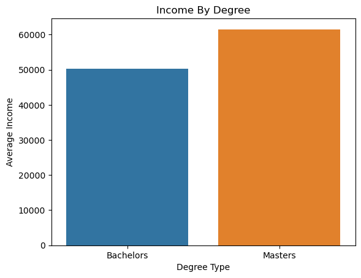

```python
# Creating a barplot to describe Average Income by Degree Type
bar = sns.barplot(data=data, x='EDUCD', y='INCWAGE', ci=None);
bar.set(title = 'Income By Degree', xlabel = 'Degree Type', ylabel = 'Average Income');
```

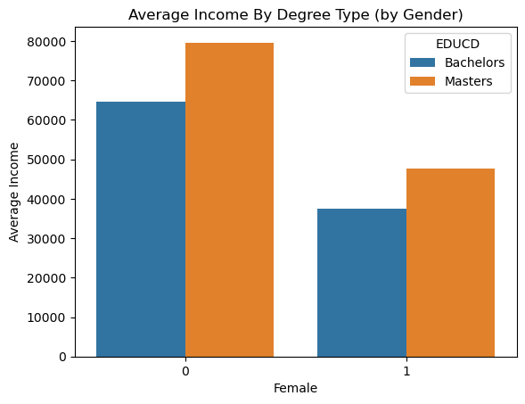

```python
# Creating a barplot to describe Average Income by Degree Type (by Gender)
bar = sns.barplot(data=data, x='Female', y='INCWAGE', hue='EDUCD', ci=None);
bar.set(title = 'Average Income By Degree Type (by Gender)', xlabel = 'Female', ylabel = 'Average Income');
```